# Project 3 - Wine Analysis

Bryan Smith

Saturday, January 10, 2015

# Introduction

This study will explore the quality of red and white wines using data available for public research. The details of the data and initial analysis can be found in Cortez et. all:

P. Cortez, A. Cerdeira, F. Almeida, T. Matos and J. Reis. Modeling wine preferences by data mining from physicochemical properties. In Decision Support Systems, Elsevier, 47(4):547-553. ISSN: 0167-9236.

The data contains the following twelve attributes for both red and white wines:

1. fixed acidity (tartaric acid - g / dm^3)
2. volatile acidity (acetic acid - g / dm^3)
3. citric acid (g / dm^3)
4. residual sugar (g / dm^3)
5. chlorides (sodium chloride - g / dm^3
6. free sulfur dioxide (mg / dm^3)
7. total sulfur dioxide (mg / dm^3)
8. density (g / cm^3)
9. pH
10. sulfates (potassium sulfate - g / dm3)
11. alcohol (% by volume)
12. quality (score between 0 and 10 - average of 3 wine expert ratings)

# Exploratory Data Analysis

We will begin the analysis by loading the data, but first I will convert all the variables but pH to g/dm^3 (g/liter).

```r
red <- read.csv("WineQualityReds.csv")
white <- read.csv("WineQualityWhites.csv")
red$type = 'red'
white$type = 'white'

wine <- rbind(red,white)
wine$type <- factor(wine$type)
wine$quality <- factor(wine$quality)

wine$density <- 1000*wine$density
wine$free.sulfur.dioxide <- wine$free.sulfur.dioxide/1000
wine$total.sulfur.dioxide <- wine$total.sulfur.dioxide/1000
summary(wine$type)
```

```
##   red white
##  1599  4898
```

```r
summary(wine$quality)
```

```
##    3    4    5    6    7    8    9
##   30  216 2138 2836 1079  193    5
```

The fact that there are so few wines in the higher and lower qualities might suggest a reclassification of quality later on.

## Box Plots of Each Variable by Quality & Type

To get a feel for the data we will explore a summary plot of each variable by type and quality. ###Density

```r
summary(wine$density)
```

```
##    Min. 1st Qu.  Median    Mean 3rd Qu.    Max.
##   987.1   992.3   994.9   994.7   997.0  1039.0
```

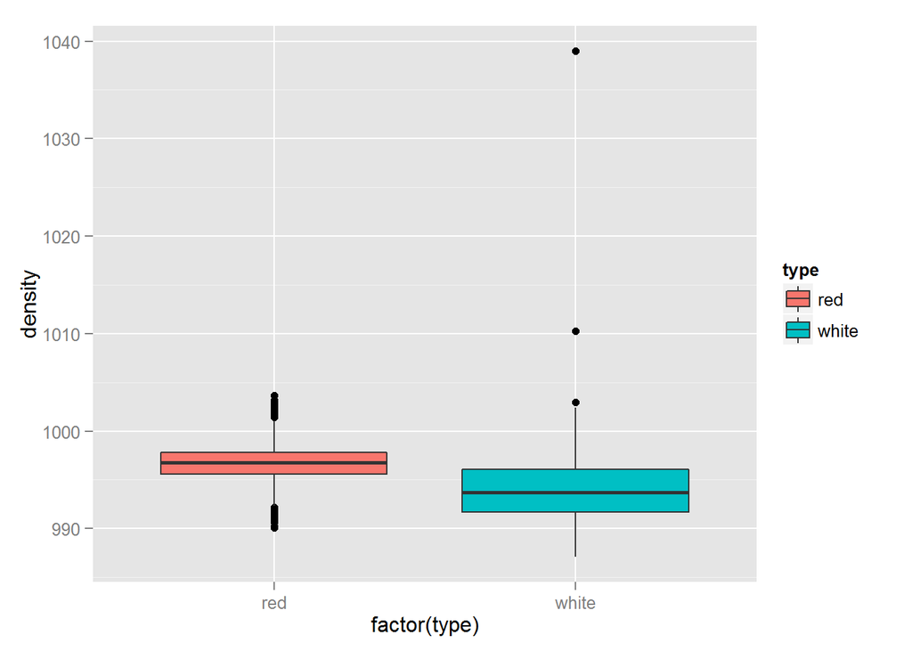

```r
ggplot(wine,aes(factor(type),density,fill=type))+geom_boxplot()
```

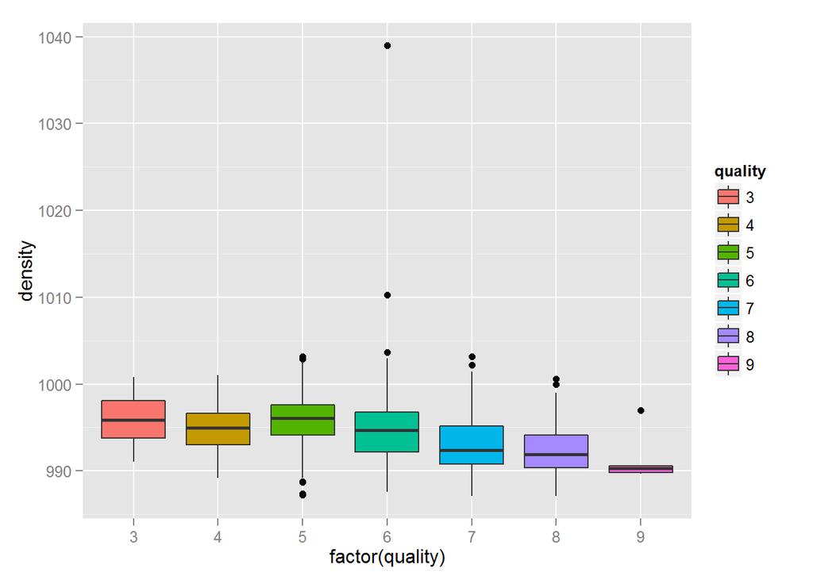

```r
ggplot(wine,aes(factor(quality),density,fill=quality))+geom_boxplot()
```

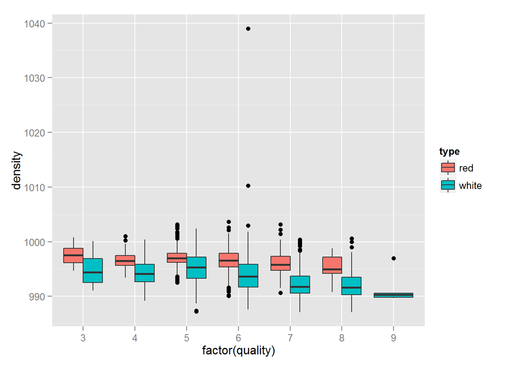

```r
ggplot(wine,aes(factor(quality),density,fill=type))+geom_boxplot()
```

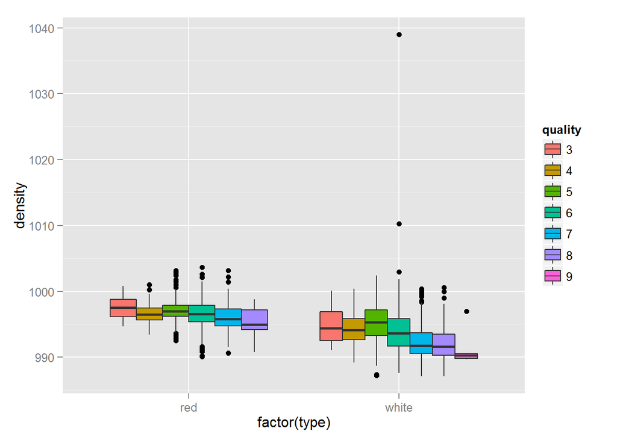

```r
ggplot(wine,aes(factor(type),density,fill=quality))+geom_boxplot()
```

White wines seem to be less dense then red wines, but there is overlap. Both tend to be less dense than water (1000 g/liter). There seems to be a slight decrease in density in higher qualities wines. This could have something to do with chemicals that have to do with wine quality are less dense or absorb more gasses.

### Fixed Acidity

Tartaric acid is found in higher concentrations in wines where grapes come from cooler climates. It is associated with the sourness of a wine.

```r
summary(wine$fixed.acidity)
```

```
##    Min. 1st Qu.  Median    Mean 3rd Qu.    Max.
##   3.800   6.400   7.000   7.215   7.700  15.900
```

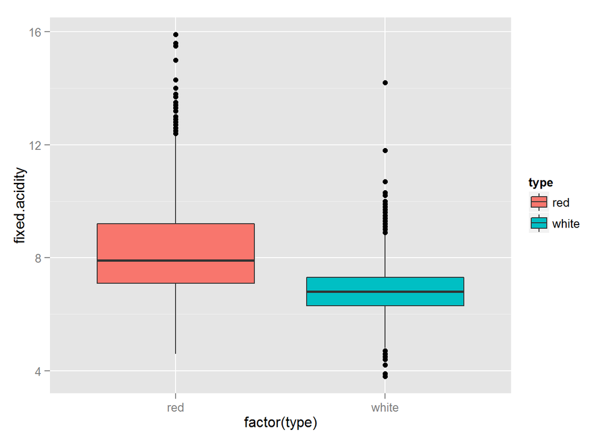

```r
ggplot(wine,aes(factor(type),fixed.acidity,fill=type))+geom_boxplot()
```

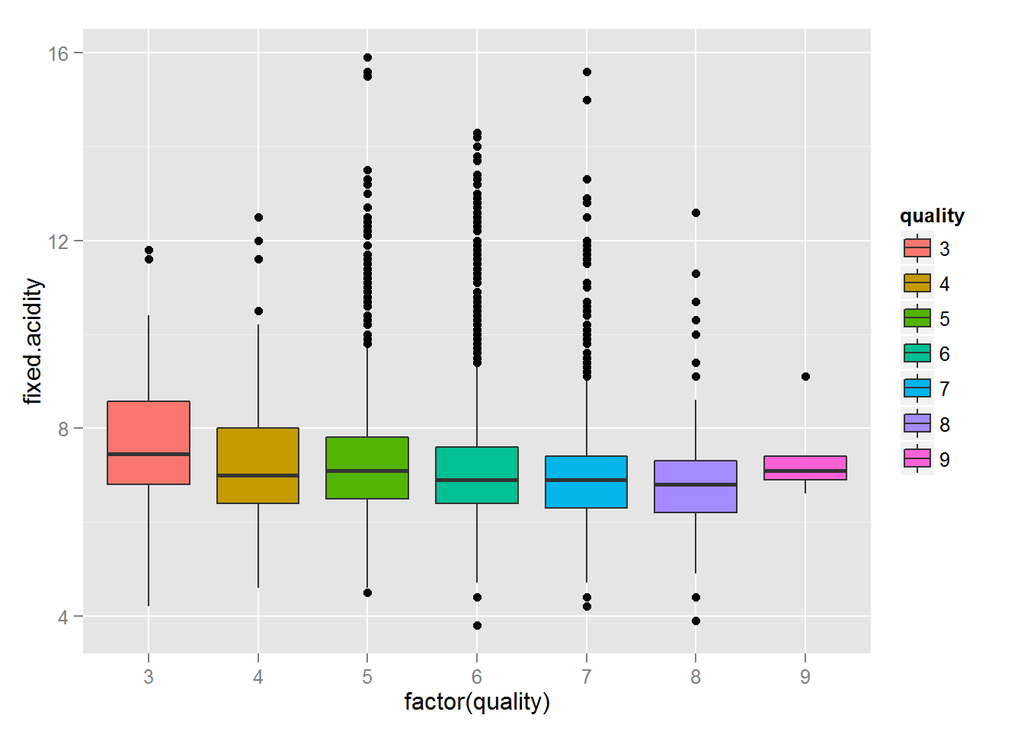

```r
ggplot(wine,aes(factor(quality),fixed.acidity,fill=quality))+geom_boxplot()
```

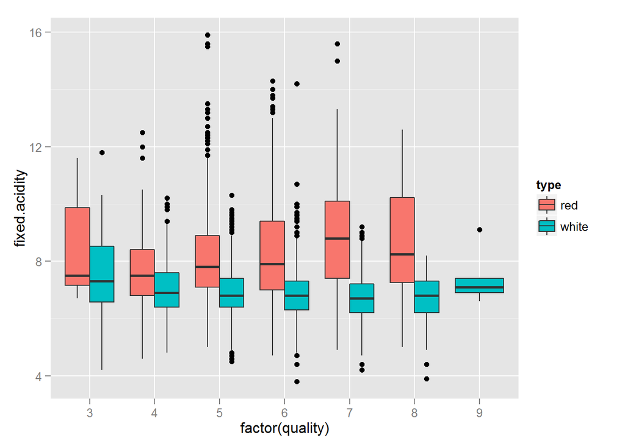

```r
ggplot(wine,aes(factor(quality),fixed.acidity,fill=type))+geom_boxplot()
```

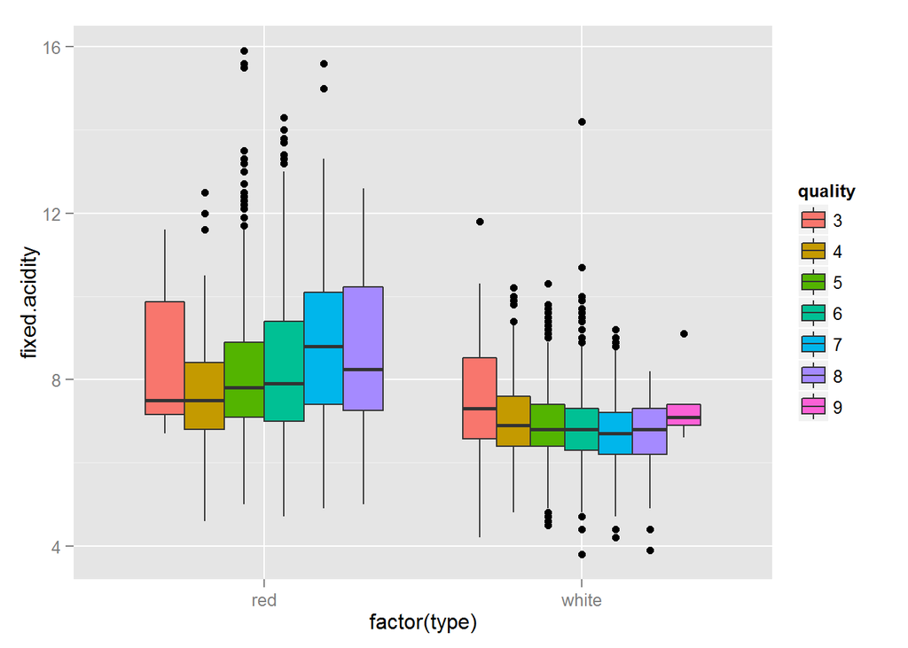

```r
ggplot(wine,aes(factor(type),fixed.acidity,fill=quality))+geom_boxplot()
```

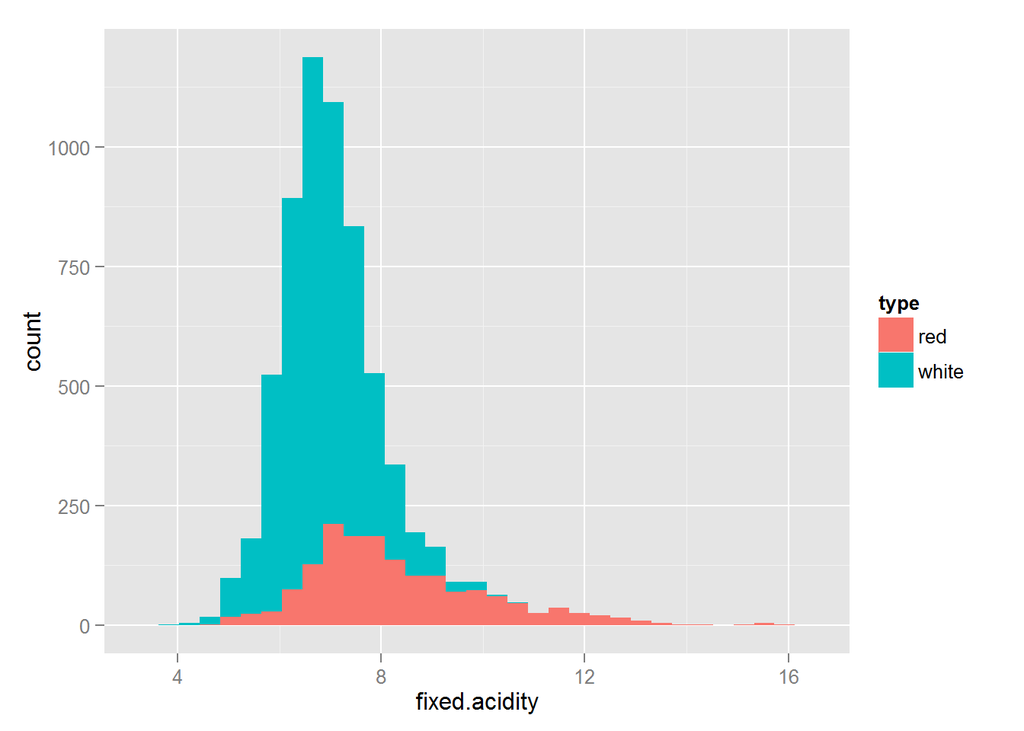

```r
ggplot(wine,aes(fixed.acidity,fill=type))+geom_histogram()
```

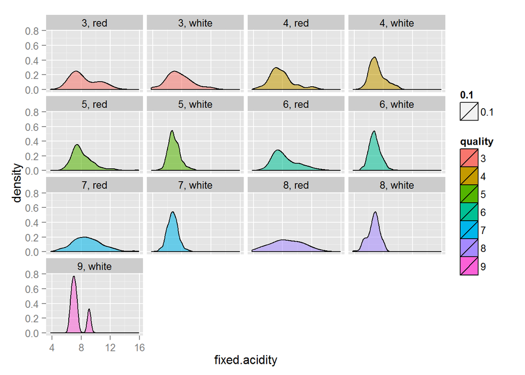

```r
ggplot(wine,aes(fixed.acidity,fill=quality,alpha=0.1))+
  geom_density()+
  facet_wrap(~quality+type)
```

The white wines typically have lower values of fixed acidity, but there is a significant overlap between the two types of wines. There does not seem to be a strong associated between quality and the amount of tartaric acid. It almost looks like in the red that there are two sources of tartaric acid, and higher quality wines reduce the second source.

### Volatile Acidity

Volatile acidity is acetic acid usually caused by bacteria. This chemical is associated with a vinegar taste in wines.

```r
summary(wine$volatile.acidity)
```

```
##    Min. 1st Qu.  Median    Mean 3rd Qu.    Max.
##  0.0800  0.2300  0.2900  0.3397  0.4000  1.5800
```

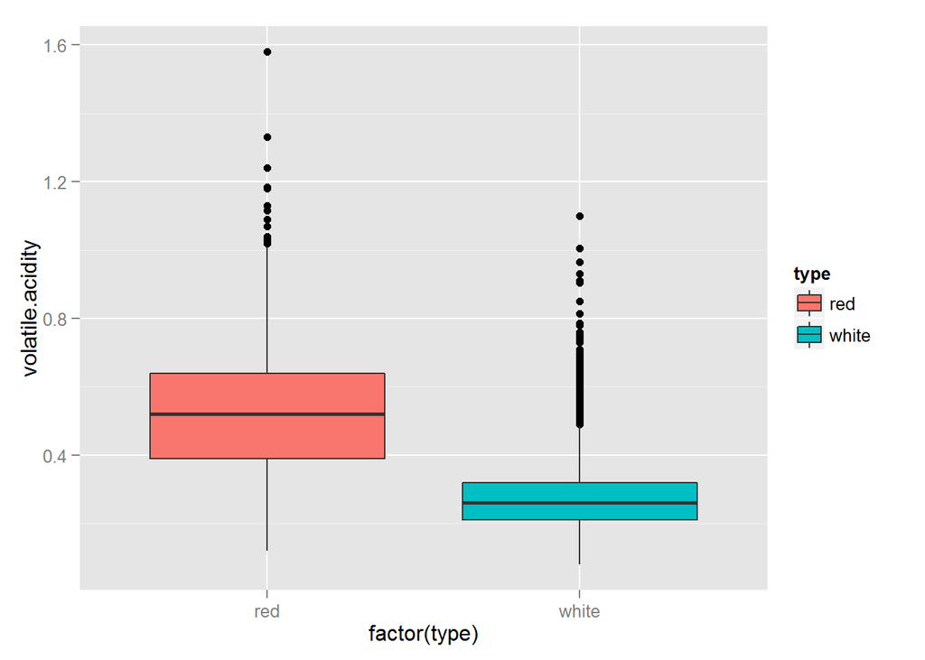

```r
ggplot(wine,aes(factor(type),volatile.acidity,fill=type))+
  geom_boxplot()
```

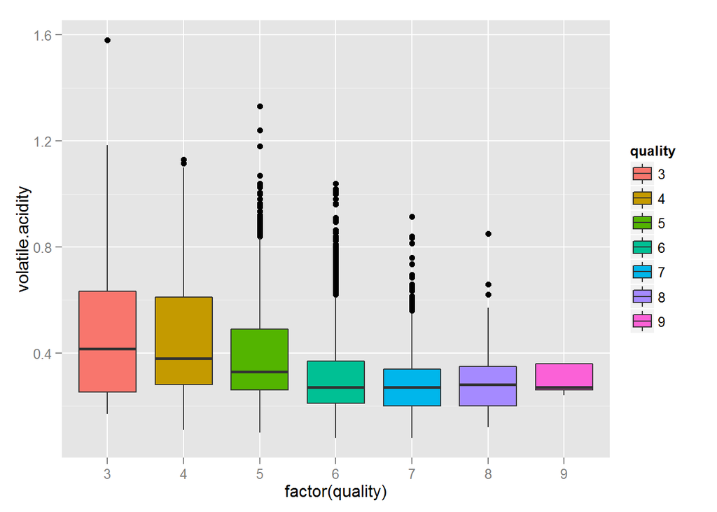

```r
ggplot(wine,aes(factor(quality),volatile.acidity,fill=quality))+
  geom_boxplot()
```

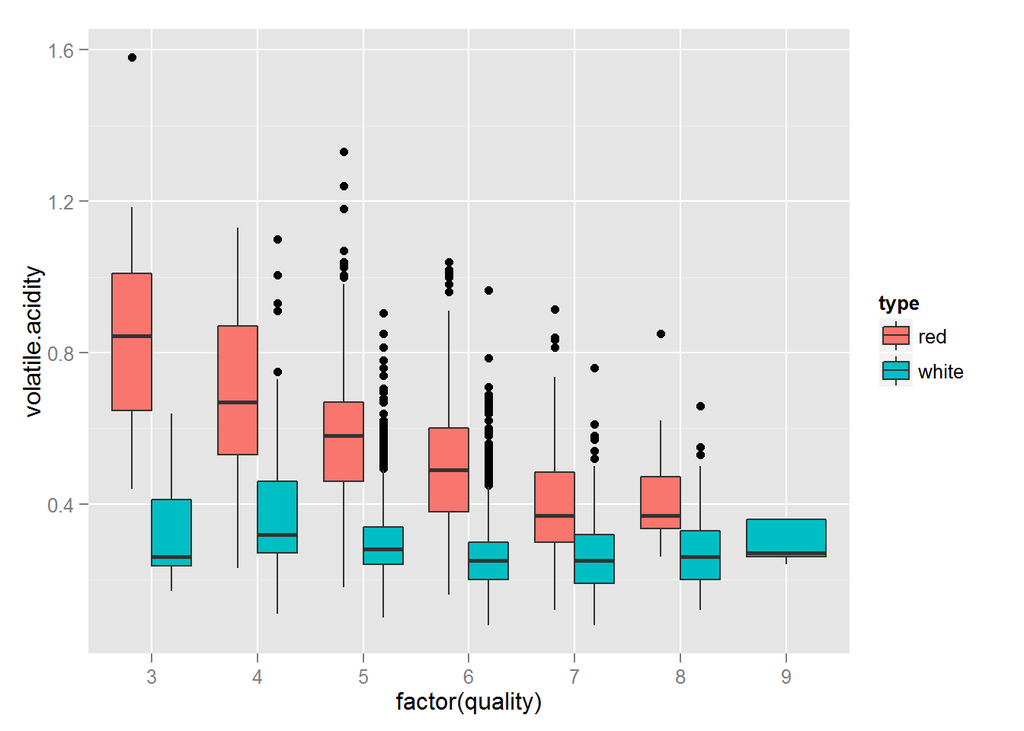

```r
ggplot(wine,aes(factor(quality),volatile.acidity,fill=type))+
  geom_boxplot()
```

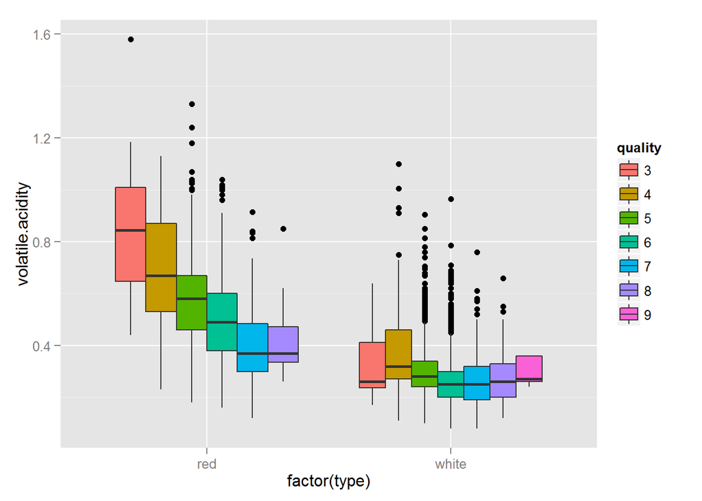

```r
ggplot(wine,aes(factor(type),volatile.acidity,fill=quality))+
  geom_boxplot()
```

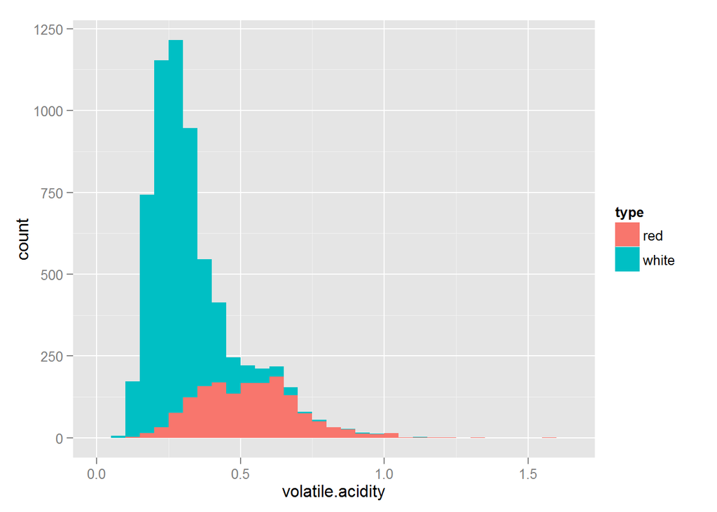

```r
ggplot(wine,aes(volatile.acidity,fill=type))+
  geom_histogram()
```

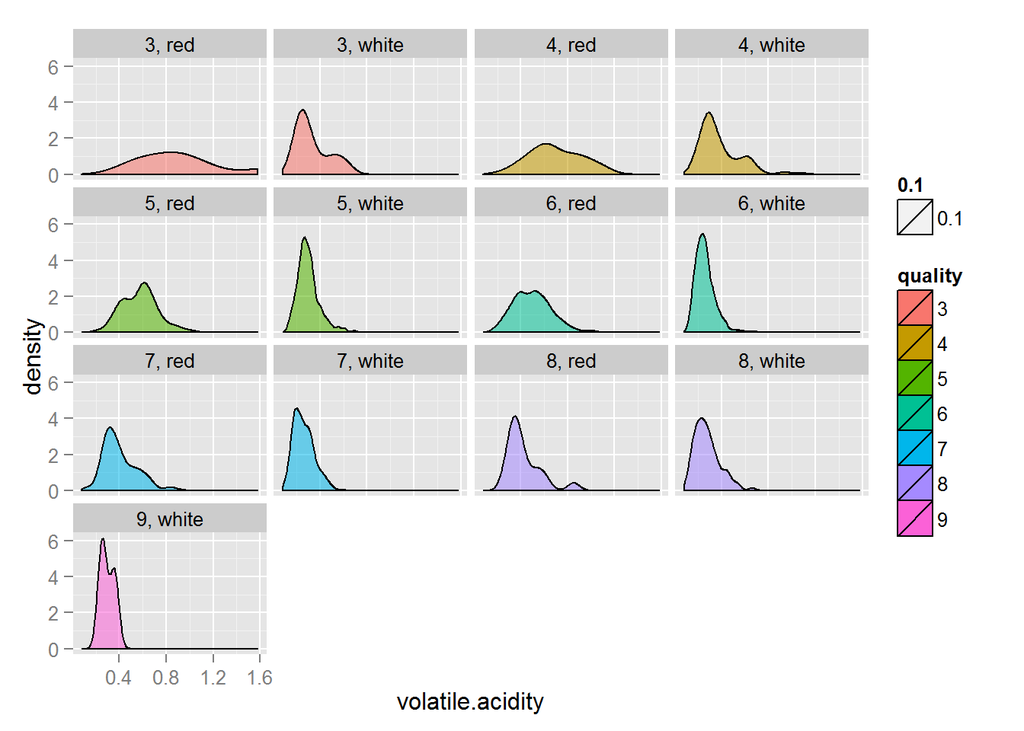

```r
ggplot(wine,aes(volatile.acidity,fill=quality,alpha=0.1))+
  geom_density()+
  facet_wrap(~quality+type)
```

White wines have lower values of volatile acidity, and there does not seem to be a strong associated with quality. There does seem to be a strong associated with lower volatile acidity with higher quality wines.

### Citric Acid

Citric acid is associated with fruitiness or liveliness of a wine. Wines low is citric acid tend to be considered ‘flat’.

```r
summary(wine$citric.acid)
```

```
##    Min. 1st Qu.  Median    Mean 3rd Qu.    Max.
##  0.0000  0.2500  0.3100  0.3186  0.3900  1.6600
```

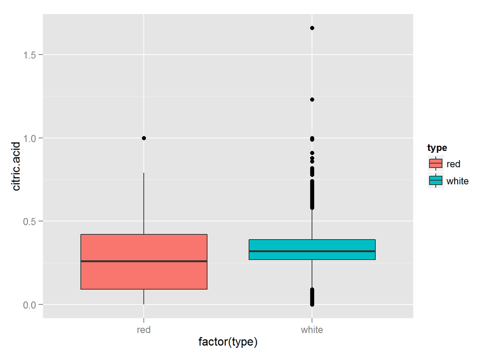

```r
ggplot(wine,aes(factor(type),citric.acid,fill=type))+geom_boxplot()
```

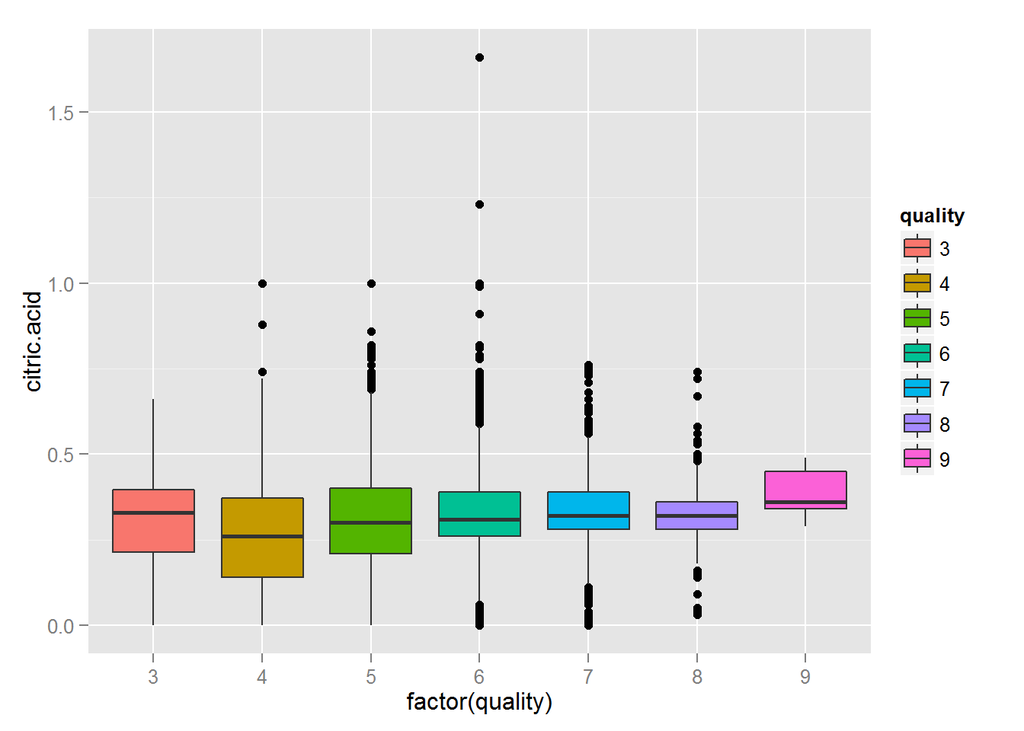

```r
ggplot(wine,aes(factor(quality),citric.acid,fill=quality))+geom_boxplot()
```

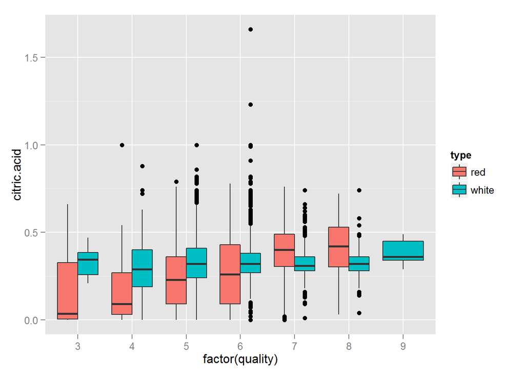

```r
ggplot(wine,aes(factor(quality),citric.acid,fill=type))+geom_boxplot()
```

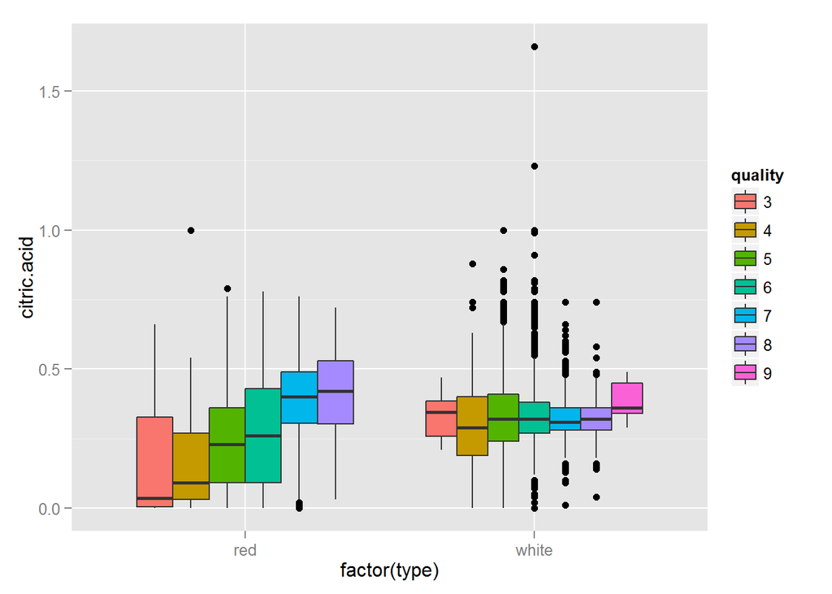

```r
ggplot(wine,aes(factor(type),citric.acid,fill=quality))+geom_boxplot()
```

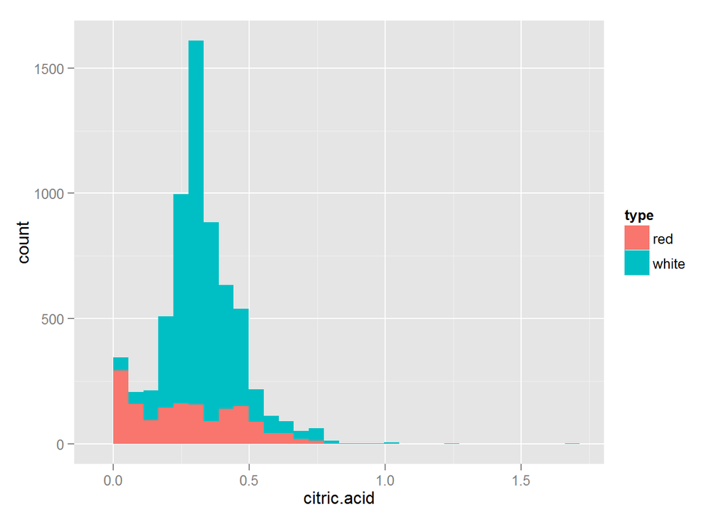

```r
ggplot(wine,aes(citric.acid,fill=type))+geom_histogram()
```

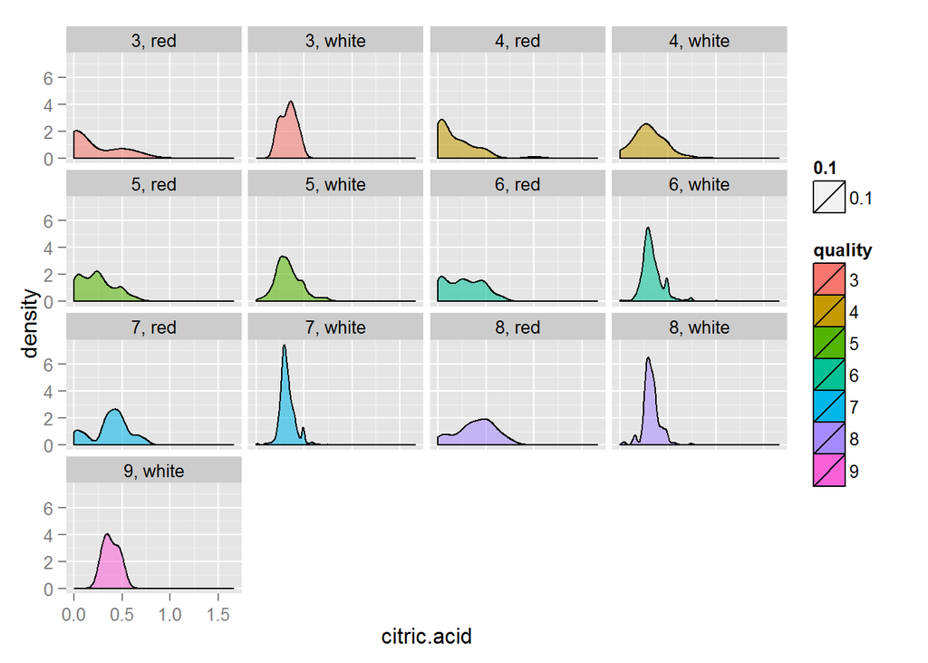

```r
ggplot(wine,aes(citric.acid,fill=quality,alpha=0.1))+
  geom_density()+facet_wrap(~quality+type)
```

White wines seem to be centered around a similar concentration of citric acid, while high quality red wines seem to have high concentrations of citric acid.

### pH

pH is the total measure of acidity of a wine that runs from 1 (acid) to 14 (base). To avoid spoilage most wines need to have a pH below 4. Most wine makers shoot for values between 3 and 3.3 for whites and 3.2-3.5 for reds.

```r
summary(wine$pH)
```

```
##    Min. 1st Qu.  Median    Mean 3rd Qu.    Max.
##   2.720   3.110   3.210   3.219   3.320   4.010
```

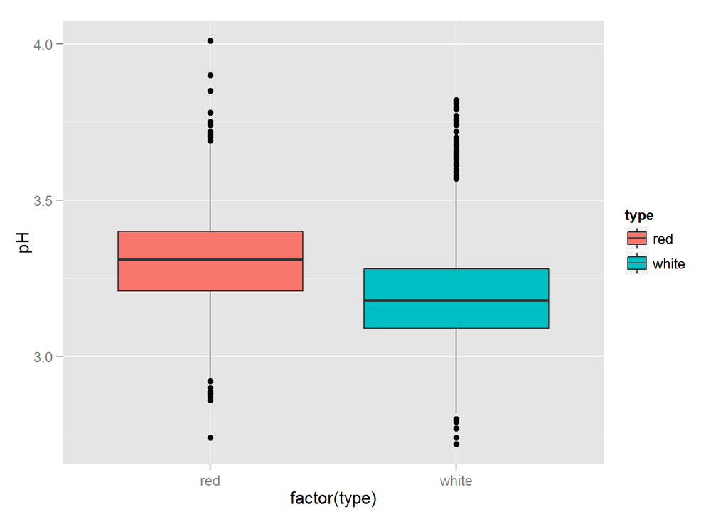

```r
ggplot(wine,aes(factor(type),pH,fill=type))+geom_boxplot()
```

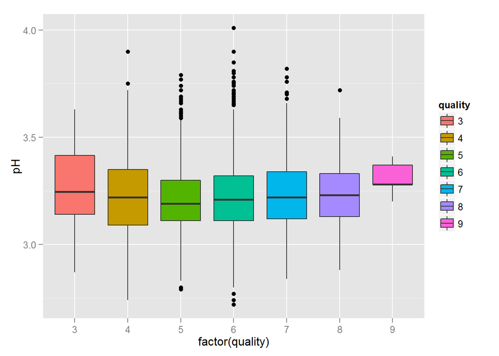

```r
ggplot(wine,aes(factor(quality),pH,fill=quality))+geom_boxplot()
```

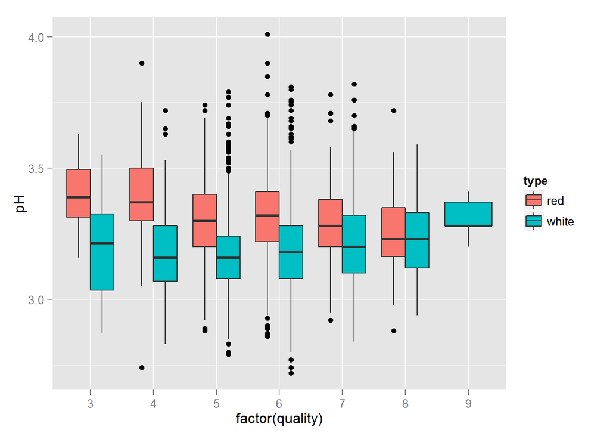

```r
ggplot(wine,aes(factor(quality),pH,fill=type))+geom_boxplot()
```

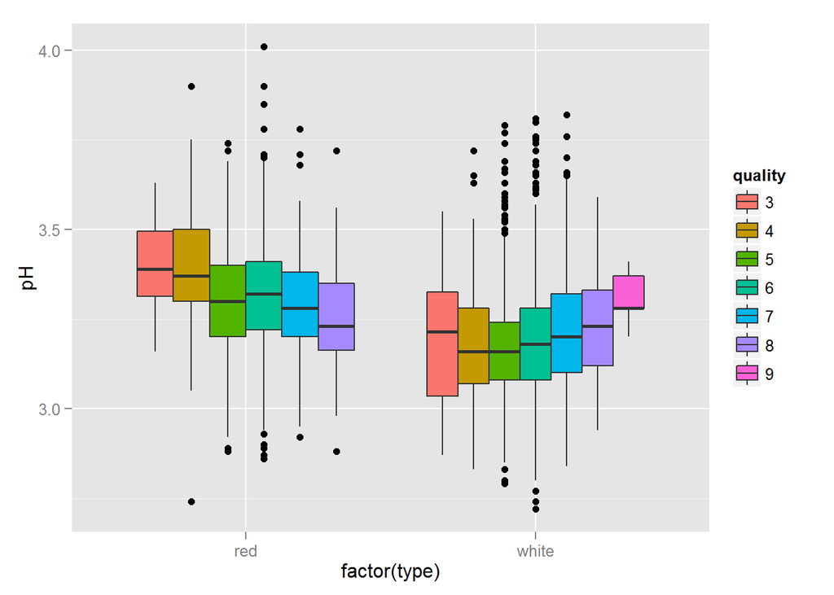

```r
ggplot(wine,aes(factor(type),pH,fill=quality))+geom_boxplot()
```

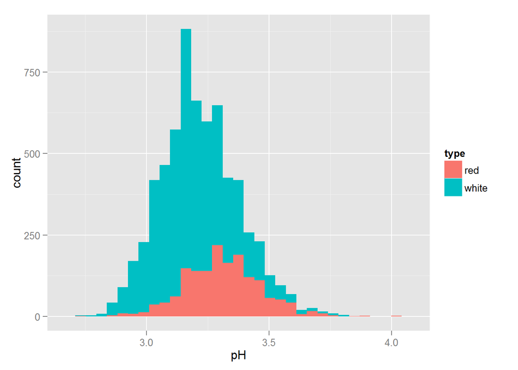

```r
ggplot(wine,aes(pH,fill=type))+geom_histogram()
```

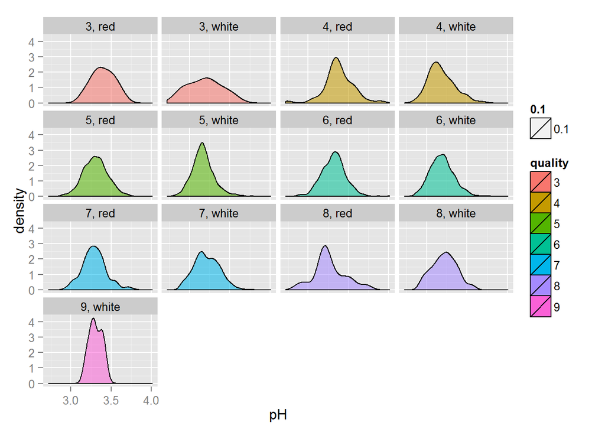

```r
ggplot(wine,aes(pH,fill=quality,alpha=0.1))+
  geom_density()+facet_wrap(~quality+type)
```

It is interesting to see the bell shapes for almost all wine types and qualities. Reading online suggest that this is an aspect of the wine that is engineered

I am wondering if the sum or ratios of these acidity are correlated to quality in any strong way.

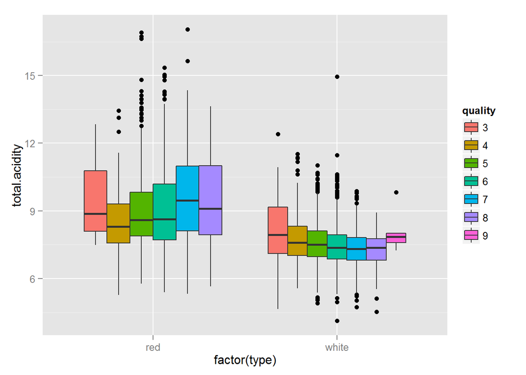

```r
wine$total.acidity = wine$citric.acid+wine$volatile.acidity+wine$fixed.acidity
ggplot(wine,aes(factor(type),total.acidity,fill=quality))+
  geom_boxplot()
```

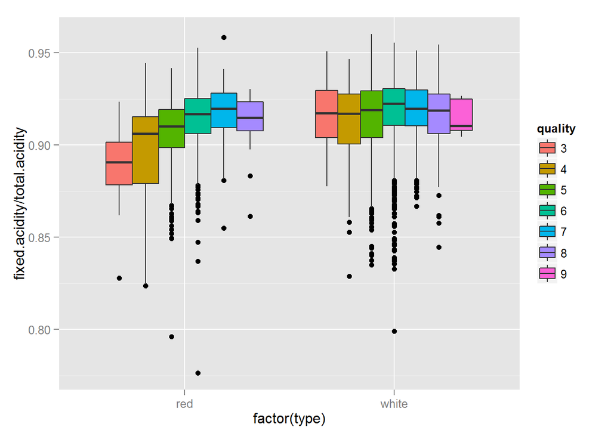

```r
ggplot(wine,aes(factor(type),fixed.acidity/total.acidity,fill=quality))+
  geom_boxplot()
```

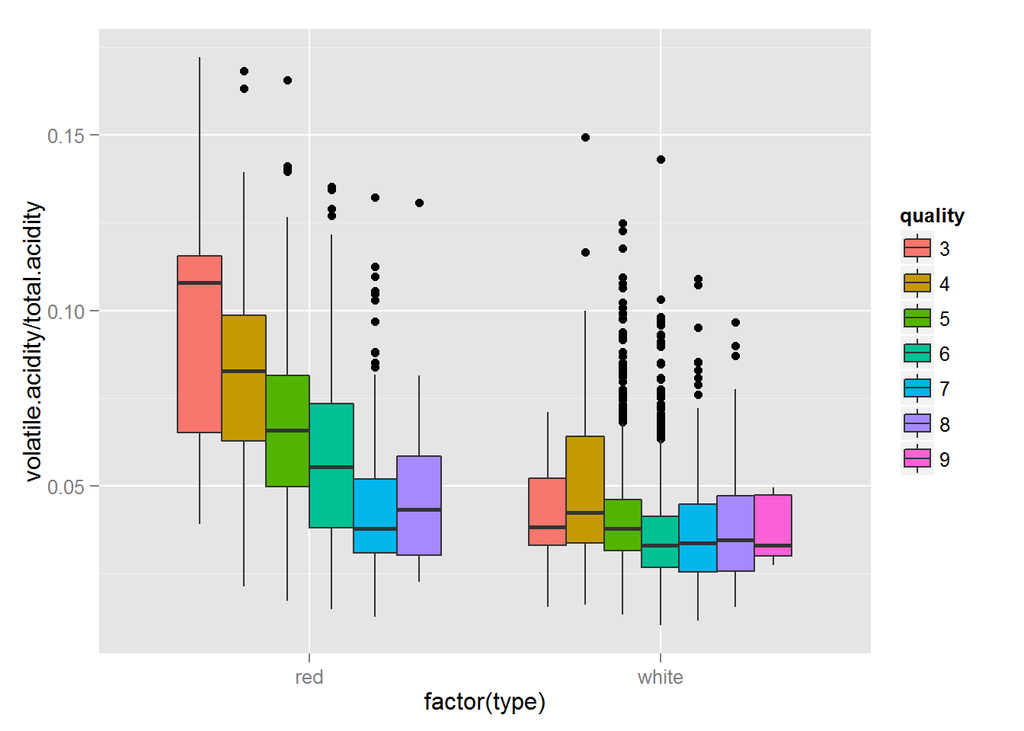

```r
ggplot(wine,aes(factor(type),volatile.acidity/total.acidity,fill=quality))+
  geom_boxplot()
```